# Part I - Loan Data from Prosper

### CLEANING DATA

#### Issue 1: Duplicate rows

#### Define

The duplicate rows will be dropped using pandas' drop_duplicates method.

#### Code

```python
# drop all duplicate rows
df_1 = df_1.drop_duplicates()
```

#### Test

```python
# dimensions of the dataframe after dropping duplicate rows
df_1.shape
```

```
(113066, 15)
```

#### Issue 2: Complex column names.

#### Define

The column names will be renamed with more suitable names using pandas' rename function.

#### Code

```python
# rename the column names
df_1.rename(columns = {'LoanKey':'loan_key', 'Term':'term', 'LoanStatus':'loan_status', 'BorrowerAPR':'borrower_APR',
                       'BorrowerRate': 'borrower_rate', 'ListingCategory (numeric)':'listing_category',
                       'EmploymentStatus':'employment_status', 'IsBorrowerHomeowner':'is_borrower_a_home_owner?',
                       'DebtToIncomeRatio': 'debt_to_income_ratio','IncomeRange':'income_range',
                       'IncomeVerifiable':'income_verifiable','StatedMonthlyIncome':'stated_monthly_income',
                       'LoanOriginalAmount':'loan_original_amount','MonthlyLoanPayment': 'monthly_loan_payment',
                       'Investors':'investors'}, inplace = True)
```

#### Test

```python
#five random rows after renaming the column names
df_1.sample(5)
```

|  | loan_key | term | loan_status | borrower_APR | borrower_rate | listing_category | employment_status | is_borrower_a_home_owner? | debt_to_income_ratio | income_range | income_verifiable | stated_monthly_income | loan_original_amount | monthly_loan_payment | investors |
| --- | --- | --- | --- | --- | --- | --- | --- | --- | --- | --- | --- | --- | --- | --- | --- |
| 73628 | DCC93668677963502FEDC40 | 36 | Completed | 0.21434 | 0.1774 | 7 | Employed | True | 0.19 | $75,000-99,999 | True | 8000.000000 | 2300 | 82.85 | 17 |
| 84849 | 49D23689423984962AED02B | 60 | Current | 0.27637 | 0.2506 | 1 | Employed | True | 0.17 | $100,000+ | True | 8566.333333 | 15000 | 440.80 | 1 |
| 26598 | 2E2936537374131665DEBEC | 36 | Current | 0.25259 | 0.2148 | 19 | Employed | True | 0.23 | $25,000-49,999 | True | 2416.666667 | 5000 | 189.61 | 57 |
| 18007 | 37D137073555196681FF5BF | 60 | Current | 0.15449 | 0.1314 | 1 | Employed | True | 0.18 | $25,000-49,999 | True | 4000.000000 | 15000 | 342.37 | 1 |
| 113836 | 584E3593776533156F2E38D | 36 | Completed | 0.23794 | 0.2001 | 3 | Self-employed | True | NaN | $100,000+ | False | 10333.333333 | 1000 | 37.17 | 30 |

#### Issue 3: Non-descriptive listing categories

#### Define

The non-descriptive listing categories will be replaced with a descriptive listing categories using .replace() method.

#### Code

```python
# replace the numbers with the actual listing category
df_1['listing_category'].replace({0:'Not Available', 1:'Debt Consolidation', 2:'Home Improvement',
                                         3:'Business', 4:'Personal Loan', 5:'Student Use', 6:'Auto', 7:'Other',
                                         8:'Baby&Adoption', 9:'Boat', 10:'Cosmetic Procedure', 11:'Engagement Ring',
                                         12:'Green Loans', 13:'Household Expenses',14:'Large Purchases', 15:'Medical/Dental',
                                         16:'Motorcycle', 17:'RV', 18:'Taxes', 19:'Vacation', 20:'Wedding Loans'}, inplace = True)
```

#### Test

```python
# five random rows in the new dataframe
df_1.sample(5)
```

|  | loan_key | term | loan_status | borrower_APR | borrower_rate | listing_category | employment_status | is_borrower_a_home_owner? | debt_to_income_ratio | income_range | income_verifiable | stated_monthly_income | loan_original_amount | monthly_loan_payment | investors |
| --- | --- | --- | --- | --- | --- | --- | --- | --- | --- | --- | --- | --- | --- | --- | --- |
| 97291 | AD2F3376680313003630EF4 | 36 | Completed | 0.13705 | 0.1300 | Not Available | Not available | True | 0.15 | Not displayed | True | 5958.333333 | 10000 | 320.02 | 291 |
| 55235 | 0825341158337497756AC4D | 36 | Completed | 0.16866 | 0.1470 | Personal Loan | Full-time | False | 0.13 | $25,000-49,999 | True | 2166.666667 | 5000 | 172.59 | 199 |
| 90023 | 6FB235895084132207D9412 | 36 | Completed | 0.11296 | 0.0920 | Debt Consolidation | Full-time | False | 0.17 | $50,000-74,999 | True | 4583.333333 | 6000 | 191.36 | 198 |
| 28677 | 66BA3387456858177FBB444 | 36 | Chargedoff | 0.29776 | 0.2900 | Not Available | Self-employed | True | 10.01 | $1-24,999 | False | 0.083333 | 20000 | 838.11 | 172 |
| 104075 | 8CBB36979693525742B2D16 | 36 | Current | 0.20626 | 0.1695 | Business | Employed | False | 0.59 | $50,000-74,999 | True | 5000.000000 | 15000 | 534.42 | 1 |

### What is/are the main feature(s) of interest in your dataset?

> The main features of interest in this dataset are Borrower APR, Borrower Rate, Term, Loan Status, Loan Original Amount, Stated Monthly Income and Monthly Loan Payment.

### What features in the dataset do you think will help support your investigation into your feature(s) of interest?

> The features in the dataset that will support an investigation into the features of interest are Listing Category, Employment Status, Is Borrower A Home Owner?, Debt to Income Ratio, Income Verifiable and Investors.

## Univariate Exploration

```python
# a function that adds x and y labels and the main title to a plot
def label_1(x, y, t):
    """
    Args:
    x (str): x-axis title
    y (str): y-axis title
    t (str): main title

    Returns:
    None
    """
    plt.xlabel(x)
    plt.ylabel(y)
    plt.title(t)
    plt.show()
```

### What does the histogram plot of Borrower APR show?

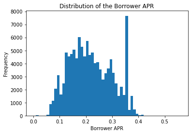

```python
# histogram plot of the borrower APR
bins = np.arange(0, df_1.borrower_APR.max()+0.05, 0.01)
plt.hist(data = df_1, x = 'borrower_APR', bins = bins)
label_1('Borrower APR', 'Frequency', 'Distribution of the Borrower APR');
```

The histogram plot shows that the distribution of the Borrower APR is bimodal. The first peak lies within 0.16 - 0.19 and the second and highest peak lies within 0.34 - 0.36.

### What does the histogram plot of the Borrower rate show?

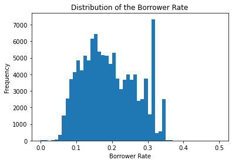

```python
# histogram plot of the borrower rate
bins = np.arange(0, df_1.borrower_rate.max()+ 0.01, 0.01)
plt.hist(data = df_1, x = 'borrower_rate', bins = bins)
label_1('Borrower Rate', 'Frequency', 'Distribution of the Borrower Rate');
```

### What does the histogram plot of the Debt to income ratio show?

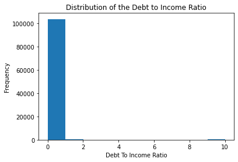

```python
# histogram plot of the debt to income ratio
plt.hist(data = df_1, x = 'debt_to_income_ratio')
label_1('Debt To Income Ratio', 'Frequency', 'Distribution of the Debt to Income Ratio');
```

There are values in this plot which falls outside the range of debt to income ratio. These are outliers because some values are capped at 10.01 i.e the debt to income ratio larger than 1000% will be returned as 1001%.

```python
# a dataframe without outliers in the debt to income ratio column
outliers = df_1['debt_to_income_ratio'] > 1
df_1_dti = df_1.loc[-outliers]
```

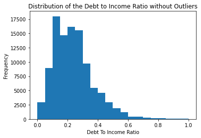

```python
# histogram plot of the debt to income ratio without outliers
bins = np.arange(0, df_1_dti.debt_to_income_ratio.max()+0.05, 0.05)
plt.hist(data = df_1_dti, x = 'debt_to_income_ratio', bins = bins)
label_1('Debt To Income Ratio', 'Frequency', 'Distribution of the Debt to Income Ratio without Outliers');
```

### What does the histogram plot of the Stated Monthly Income show?

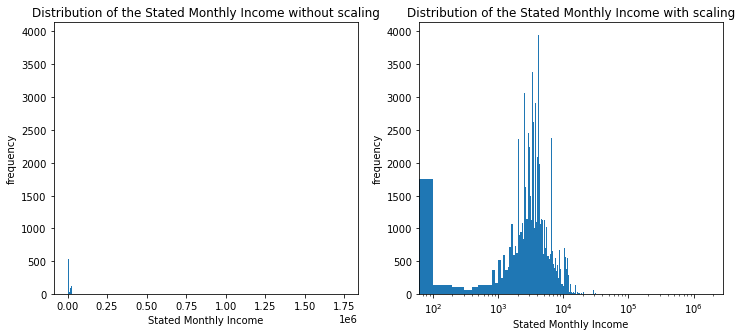

```python
# histogram plot of the stated monthly income
plt.figure(figsize = [12, 5])
bins = np.arange(0, df_1.stated_monthly_income.max()+100, 100)

#histogram on the left
plt.subplot(1,2,1)
plt.hist(data = df_1, x = 'stated_monthly_income', bins = bins)
plt.title('Distribution of the Stated Monthly Income without scaling')
plt.xlabel('Stated Monthly Income')
plt.ylabel('frequency')

#histogram on the right
plt.subplot(1,2,2)
plt.hist(data = df_1, x = 'stated_monthly_income', bins = bins)
plt.xscale('log')
plt.title('Distribution of the Stated Monthly Income with scaling')
plt.xlabel('Stated Monthly Income')
plt.ylabel('frequency');
```

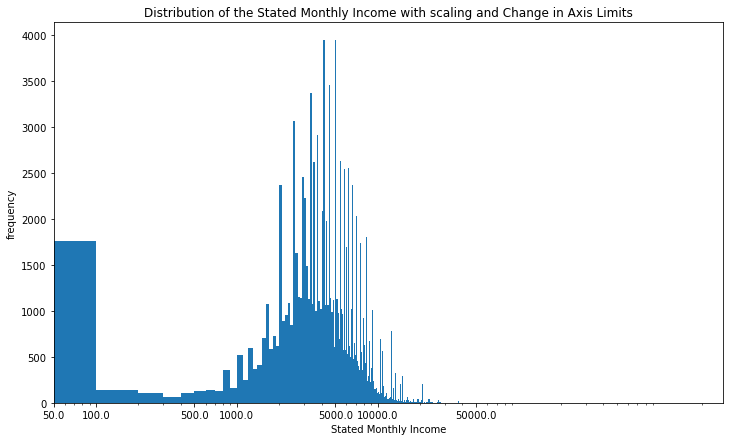

```python
# Scale the x-axis to log-type, change the axis limits, and increase the x-ticks
plt.figure(figsize = [12, 7])
bins = np.arange(0, df_1.stated_monthly_income.max()+100, 100)
ticks = [ 5e1, 1e2, 5e2, 1e3, 5e3, 1e4, 5e4]
labels = ['{}'.format(v) for v in ticks]
plt.hist(data = df_1, x = 'stated_monthly_income', bins = bins)
plt.xscale('log')
plt.xticks(ticks, labels)
label_1('Stated Monthly Income', 'frequency','Distribution of the Stated Monthly Income with scaling and Change in Axis Limits');
```

The distribution of the Stated Monthly Income is bimodal and right skewed.

### What is the maximum loan original amount?

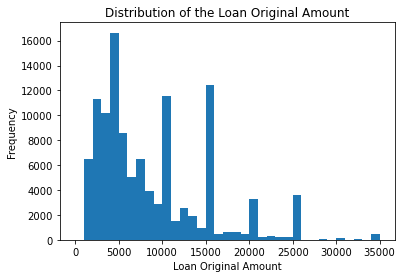

```python
# histogram plot of the loan original amount
bins = np.arange(0, df_1.loan_original_amount.max()+1000, 1000)
plt.hist(data = df_1, x = 'loan_original_amount', bins = bins)
label_1('Loan Original Amount', 'Frequency', 'Distribution of the Loan Original Amount');
```

### What does the histogram plot of the Monthly Loan Payment show?

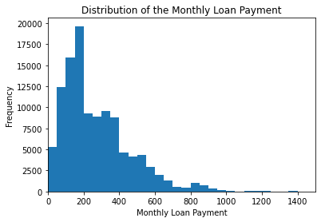

```python
# histogram plot of the monthly loan payment
bins = np.arange(0, df_1.monthly_loan_payment.max()+50, 50)
plt.hist(data = df_1, x = 'monthly_loan_payment', bins = bins)
plt.xlim((0,1500))
label_1('Monthly Loan Payment', 'Frequency', 'Distribution of the Monthly Loan Payment');
```

The distribution of the monthly loan payment is unimodal and right skewed.

### What is the maximum number of investors?

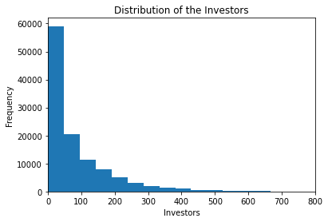

```python
# histogram plot of the investors
bins = np.arange(0, df_1.investors.max()+5, 5)
plt.hist(data = df_1, x = 'investors', bins = 25)
plt.xlim((0, 800))
label_1('Investors', 'Frequency', 'Distribution of the Investors');
```

From the plot above, it can be inferred that maximum number of investors fall within 0-100.

### What is the highest length of loans in months?

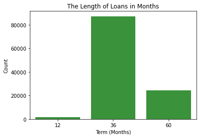

```python
# a bar plot which shows the count of each length of loans in months
color = sb.color_palette()[2]
sb.countplot(data = df_1, x = 'term', color = color)
label_1('Term (Months)', 'Count', 'The Length of Loans in Months');
```

This bar plot shows that most loans are given out for a length of 36 months(3 years), followed by 60 months (5 years) and less loans are given out for a length of 12 months (1 year).

### Which loan status is the highest?

```python
loan_status_count = df_1['loan_status'].value_counts()

n_loan_status = df_1['loan_status'].value_counts().sum()
```

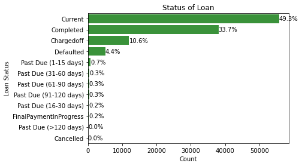

```python
# a bar plot which shows the count of each status of loan
color = sb.color_palette()[2]
sb.countplot(data = df_1, y = 'loan_status', color = color, order = loan_status_count.index)


for i in range (loan_status_count.shape[0]):
    count = loan_status_count[i]
    pct_string = '{:0.1f}%'.format(100*count/n_loan_status)
    plt.text(count+1, i, pct_string, va = 'center')

label_1('Count', 'Loan Status', 'Status of Loan');
```

The loan status with the maximum frequency is current followed by completed. Loans that are past due have the minimum frequency.This implies that most borrowers pay their loans in time.

### What is the highest category of listing selected by the borrower?

```python
# frequency of each unique value
listing_category_count = df_1['listing_category'].value_counts()
n_listing_category = df_1['listing_category'].value_counts().sum()
```

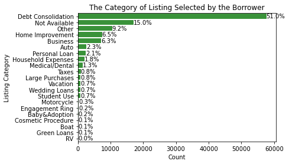

```python
# a bar plot which shows the count of the category of listing selected by the borrower
color = sb.color_palette()[2]
sb.countplot(data = df_1, y = 'listing_category', color = color, order = listing_category_count.index)

for i in range (listing_category_count.shape[0]):
    count = listing_category_count[i]
    pct_string = '{:0.1f}%'.format(100*count/n_listing_category)
    plt.text(count+1, i, pct_string, va = 'center')

label_1('Count', 'Listing Category', 'The Category of Listing Selected by the Borrower');
```

This plot shows that most loans are obtained for the purpose of debt consolidation.

### Which employment status has the highest count?

```python
# frequency of each unique value
employment_status_count = df_1['employment_status'].value_counts()
n_employment_status = df_1['employment_status'].value_counts().sum()
```

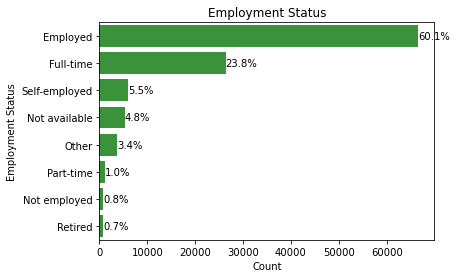

```python
# a bar plot which shows the count of the borrowers' employment status
color = sb.color_palette()[2]
sb.countplot(data = df_1, y = 'employment_status', color = color, order = employment_status_count.index)

for i in range (employment_status_count.shape[0]):
    count = employment_status_count[i]
    pct_string = '{:0.1f}%'.format(100*count/n_employment_status)
    plt.text(count+1, i, pct_string, va = 'center')


label_1('Count','Employment Status', 'Employment Status');
```

From the bar plot above, it can be inferred that most borrowers are employed and less borrowers are either not employed or retired.

### Are most borrowers home owners?

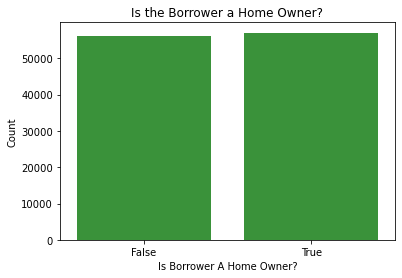

```python
# a bar plot which shows the count for whether the borrower is a home owner or not
color = sb.color_palette()[2]
sb.countplot(data = df_1, x = 'is_borrower_a_home_owner?', color = color)
label_1('Is Borrower A Home Owner?', 'Count','Is the Borrower a Home Owner?');
```

From the bar plot above, it can be inferred that most borrowers are home owners.

### What is the highest income range of the borrowers?

```python
# frequency of each unique value
income_range_count = df_1['income_range'].value_counts()
n_income_range = df_1['income_range'].value_counts().sum()
```

[figure not shown]

```python
# a bar plot which shows the count for the borrowers' income range
plt.figure(figsize = [10,5])
color = sb.color_palette()[2]
#order = ['$0', '$1-24,999', '$25,000-49,999', '$50,000-74,999', '$75,000-99,000', '$100,000', 'Not employed', 'Not displayed']
sb.countplot(data = df_1, y = 'income_range', color = color)#, order = order)

for i in range (income_range_count.shape[0]):
    count = income_range_count[i]
    pct_string = '{:0.1f}%'.format(100*count/n_income_range)
    plt.text(count+1, i, pct_string, va = 'center')


label_1('Income Range', 'Count','Income Range');
```

The highest income range is ($ 25,000-49,999) followed by ($ 50,000-74,999). The lowest income range is $ 0 followed by not employed borrowers.

### Do most borrowers have verifiable income?

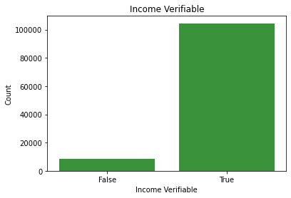

```python
# a bar plot which shows the count for whether the borrowers' income is verifiable or not
color = sb.color_palette()[2]
sb.countplot(data = df_1, x = 'income_verifiable', color = color)
label_1('Income Verifiable', 'Count','Income Verifiable');
```

From the bar plot above, it can be inferred that most borrowers have verifiable income.

### Discuss the distribution(s) of your variable(s) of interest. Were there any unusual points? Did you need to perform any transformations?

> The distributions of the variables of interest are mostly unimodal and right skewed. There were unusual points in the histogram plot of the Stated Monthly Income. I performed log transformation on the Stated Monthly Income to focus on the most relevant parts.

### Of the features you investigated, were there any unusual distributions? Did you perform any operations on the data to tidy, adjust, or change the form of the data? If so, why did you do this?

> There was an unusual distribution in the histogram of the debt to income ratio. There were values greater than 1 which is unlikely because the debt to income ratio is not greater than 1. These points were considered as outliers and were removed from the data and assigned to a new dataframe. The outliers were removed because they represent errors in the data.

## Bivariate Exploration

### What is the relationship between Borrower APR and Term(Months) ?

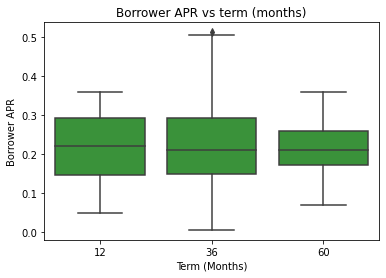

```python
# distribution of borrower APR across the length of loans in months
color = sb.color_palette()[2]
ax1 = sb.boxplot(data = df_1, x = 'term', y = 'borrower_APR', color = color)
label_1('Term (Months)', 'Borrower APR', 'Borrower APR vs term (months)');
```

From this box plot, we can quickly see that the median borrower APR is higher at 12 months and the spread of the borrower APR distribution is larger at 36 months.There is also an outlier at 36 months and the median borrower APR at 36 and 60 months are similar.

### What is the relationship between Borrower Rate and Term(Months) ?

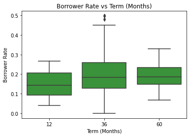

```python
# distribution of borrower rate across the length of loans in months
color = sb.color_palette()[2]
sb.boxplot(data = df_1, x = 'term', y = 'borrower_rate', color = color)
label_1('Term (Months)', 'Borrower Rate', 'Borrower Rate vs Term (Months)');
```

From this box plot, we can quickly see that the median borrower rate is higher at 36 months and 60 months. The spread of the borrower rate distribution is larger at 36 months and there are two outliers at 36 months.

### What is the relationship between Loan Original Amount and Monthly Loan Payment ?

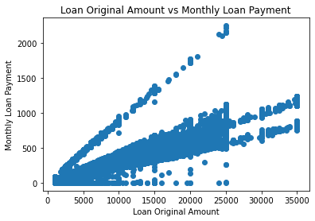

```python
# relationship between loan original amount and monthly loan payment
plt.scatter(data = df_1, x = 'loan_original_amount', y = 'monthly_loan_payment')
label_1('Loan Original Amount', 'Monthly Loan Payment', 'Loan Original Amount vs Monthly Loan Payment');
```

The plot above shows a positive correlation between Loan Original Amount and Monthly Loan Payment.

### Does the borrower's home ownership affect the loan status?

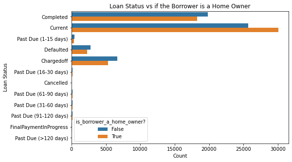

```python
# the relationship between loan status and if the borrower is a home owner
plt.figure(figsize = [8, 5])
sb.countplot(data = df_1, hue = 'is_borrower_a_home_owner?', y = 'loan_status')
label_1('Count', 'Loan Status', 'Loan Status vs if the Borrower is a Home Owner' );
```

From the plot above, most of the borrowers with loan status on current are home owners. Whether the borrower is a home owner or not does not have a major effect on the loan status.

### Does the borrower's verifiable income have any effect on the loan status?

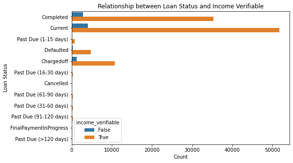

```python
# the relationship between loan status and income verifiable
plt.figure(figsize = [8, 5])
sb.countplot(data = df_1, hue = 'income_verifiable', y = 'loan_status')
label_1('Count', 'Loan Status', 'Relationship between Loan Status and Income Verifiable');
```

From the plot above, most of the borrowers that have completed, current, defaulted and chargedoff loans have verifiable income. Whether the borrowers' income is verifiable or not does not have a major effect on the loan status.

### What is the relationship among the Borrower APR and each Listing Categories?

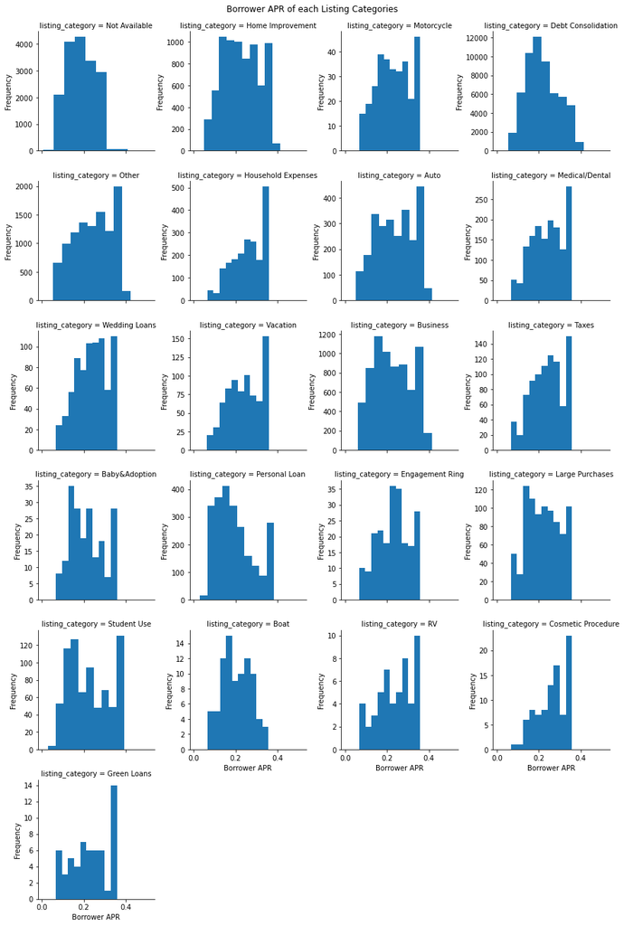

```python
# a facet grid of the borrower APR for each listing categories
g = sb.FacetGrid(data = df_1, col = 'listing_category', col_wrap=4, sharey=False)
g.map(plt.hist, "borrower_APR")
g.fig.suptitle("Borrower APR of each Listing Categories", y = 1.01)
g.set(xlabel = 'Borrower APR',
      ylabel = 'Frequency');
```

### Talk about some of the relationships you observed in this part of the investigation. How did the feature(s) of interest vary with other features in the dataset?

> The income verifiable and the borrower's home ownership has no effect on the main features of interest.The spread of the borrower rate and borrower APR distribution is larger at 36 months.

### Did you observe any interesting relationships between the other features (not the main feature(s) of interest)?

> The loan original amount and monthly loan payment are highly correlated.

## Multivariate Exploration

### Which variables have the strongest correlation ?

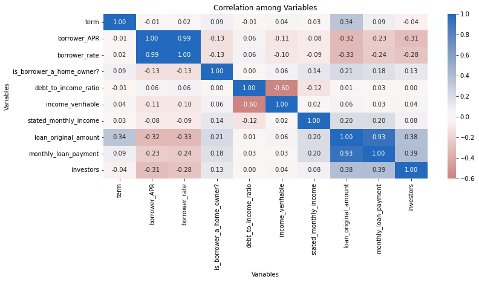

```python
# The correlation among variables
plt.figure(figsize = [12, 5])
sb.heatmap(df_1.corr(), annot = True, fmt = '.2f', cmap = 'vlag_r', center = 0)
label_1('Variables', 'Variables', 'Correlation among Variables');
```

The Borrower Rate and Borrower APR are strongly positive correlated (0.99). Followed by the Loan Original Amount and Monthly Loan Payment (0.93). Income Verifiable and Debt to Income Ratio are negatively correlated (-0.60).

### What is the relationship between borrower rate and borrower APR by term of loans?

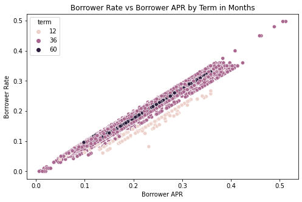

```python
# Relationship between the borrower rate,borrower APR by term of loans
plt.figure(figsize = [8, 5])
sb.scatterplot(data = df_1, x = 'borrower_APR', y = 'borrower_rate', hue = 'term')
label_1('Borrower APR', 'Borrower Rate', 'Borrower Rate vs Borrower APR by Term in Months');
```

From the plot above, there is a higher positive correlation between borrower rate and borrower APR in borrowers with 36 months and 60 months as the term of loans compared to borrowers with 12 months as the term of loans.

### What is the relationship between monthly loan payment and loan original amount by term of loans?

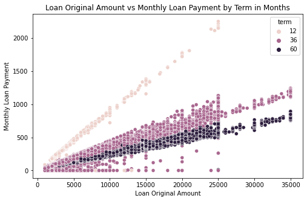

```python
# Relationship between the monthly loan payment, loan original amount by term of loans
plt.figure(figsize = [8, 5])
sb.scatterplot(data = df_1, x = 'loan_original_amount', y = 'monthly_loan_payment', hue = 'term')
label_1('Loan Original Amount', 'Monthly Loan Payment', 'Loan Original Amount vs Monthly Loan Payment by Term in Months');
```

From the plot above, there is a higher positive correlation between monthly loan payment and loan original amount in borrowers with 12 months as the term of loans compared to borrowers with 36 and 60 months as the term of loans.

### Talk about some of the relationships you observed in this part of the investigation. Were there features that strengthened each other in terms of looking at your feature(s) of interest?

> Yes, there were features that strengthened each other. The Borrower Rate and Borrower APR are strongly positive correlated (0.99). Followed by the Loan Original Amount and Monthly Loan Payment (0.93). Income Verifiable and Debt to Income Ratio are negatively correlated (-0.60).

### Were there any interesting or surprising interactions between features?

> There was an interesting interaction among the monthly loan payment, loan original amount and term of loans. There is a higher positive correlation between monthly loan payment and loan original amount in borrowers with 12 months as the term of loans compared to borrowers with 36 and 60 months as the term of loans.

## Conclusions

Many borrowers select 'debt consolidation' as the listing category, take loans for 36 months and are also employed. Whether the borrower is a home owner or not does not affect the loan status. There was an unusual distribution in the histogram of the debt to income ratio. There were values greater than 1 which is unlikely because the debt to income ratio is not greater than 1.These points were considered as outliers and were removed from the data and assigned to a new dataframe. The outliers were removed because they represent errors in the data. There was an interesting interaction among the monthly loan payment, loan original amount and term of loans. There is a higher positive correlation between monthly loan payment and loan original amount in borrowers with 12 months as the term of loans compared to borrowers with 36 and 60 months as the term of loans.